# Exploring the Credit Card data

## Setup

### Load packages

```r
library(ggplot2)
library(dplyr)
library(tidyverse)
```

### Load data

```r
df=read.csv("creditBalance.csv")
```

## Part 1: Data

```r
df = df %>%
  mutate(bal_to_limit_ratio=Balance/Limit)
df.new=select(df,-Gender,-Student,-Married)
# df.new1 = df.new %>%
#   mutate(bal_to_limit_ratio=Balance/Limit)
```

## Part 2: Questions to address

**Quesion 1:** What does the data and column say?

**Quesion 2:**Can we find relation between different columns?

**Quesion 3:** Interprete using graphical tool.

## Part 3: Exploratory data analysis

**Quesion 1:**

```r
dim(df)
```

```
## [1] 310  11
```

```r
names(df)
```

```
##  [1] "Income"             "Limit"              "Rating"
##  [4] "Cards"              "Age"                "Education"
##  [7] "Gender"             "Student"            "Married"
## [10] "Balance"            "bal_to_limit_ratio"
```

So the data set called “creditBalance” consists of 310 rows and 11 columns named “Income” “Limit” “Rating” “Cards” “Age” “Education” “Gender” “Student” “Married” “bal_to_limit_ratio” and “Balance” where Gender, Student, Married are nominal categorical and we can think Cards, education as ordinal variables(Although I will do some numerical analysis on cards) and the rest are numerical.

```r
summary(df.new)
```

```
##      Income           Limit           Rating          Cards
##  Min.   : 10.35   Min.   : 1160   Min.   :126.0   Min.   :1.000
##  1st Qu.: 23.15   1st Qu.: 3976   1st Qu.:304.0   1st Qu.:2.000
##  Median : 37.14   Median : 5147   Median :380.0   Median :3.000
##  Mean   : 49.98   Mean   : 5485   Mean   :405.1   Mean   :2.997
##  3rd Qu.: 63.74   3rd Qu.: 6453   3rd Qu.:469.0   3rd Qu.:4.000
##  Max.   :186.63   Max.   :13913   Max.   :982.0   Max.   :9.000
##       Age          Education        Balance       bal_to_limit_ratio
##  Min.   :23.00   Min.   : 5.00   Min.   :   5.0   Min.   :0.002286
##  1st Qu.:42.00   1st Qu.:11.00   1st Qu.: 338.0   1st Qu.:0.079930
##  Median :55.50   Median :14.00   Median : 637.5   Median :0.121081
##  Mean   :55.61   Mean   :13.43   Mean   : 671.0   Mean   :0.115588
##  3rd Qu.:69.00   3rd Qu.:16.00   3rd Qu.: 960.8   3rd Qu.:0.151530
##  Max.   :98.00   Max.   :20.00   Max.   :1999.0   Max.   :0.276930
```

**RQuesion 2:**

```r
library(dplyr)
table(df$Gender,df$Student)
```

```
##
##           No Yes
##    Male  130  15
##   Female 141  24
```

We can go a liitle ahead;

```r
library(dplyr)
df %>% group_by(., Gender,Student) %>%
 dplyr:: select(., Gender, Student, Income, Balance) %>%
  summarise(., Mean_Inc=mean(Income), Mean_Bal=mean(Balance),n())
```

```
## # A tibble: 4 × 5
## # Groups:   Gender [2]
##   Gender   Student Mean_Inc Mean_Bal `n()`
##   <chr>    <chr>      <dbl>    <dbl> <int>
## 1 " Male"  No          51.1     641.   130
## 2 " Male"  Yes         48.6    1005.    15
## 3 "Female" No          49.5     636.   141
## 4 "Female" Yes         47.8     834.    24
```

We have 130 male non-student, 15 male student, 141 female non-student and 24 female student. We can see that if a user is student they have less income but more balance. Usually the male students have a significant amount of high balance 1004.53.

```r
df %>% group_by(., Married) %>%
  select(., Married, Income, Balance) %>%
  summarise(., Mean_Inc=mean(Income), Mean_Bal=mean(Balance),n())
```

```
## # A tibble: 2 × 4
##   Married Mean_Inc Mean_Bal `n()`
##   <chr>      <dbl>    <dbl> <int>
## 1 No          48.3     687.   118
## 2 Yes         51.0     661.   192
```

We have 192 married user and 118 unmarried. Moreover, the married user earns more and keep balance lower than the other.

```r
library(dplyr)
df1=df %>% group_by(., Education) %>%
  select(., Education, Income, Balance) %>%
  summarise(., Mean_Inc=mean(Income), Mean_Bal=mean(Balance),number=n())
  df1[order(df1$number),]
```

```
## # A tibble: 16 × 4
##    Education Mean_Inc Mean_Bal number
##        <int>    <dbl>    <dbl>  <int>
##  1         5     34.1     863       1
##  2        20     37.6     421       2
##  3         6     65.5     694.      4
##  4         7     47.2     594.      7
##  5        19     45.9     679.      8
##  6         8     70.3     575.     12
##  7        10     38.4     648.     17
##  8        18     41.6     541.     18
##  9         9     44.0     824.     21
## 10        11     63.0     606.     24
## 11        13     43.3     537.     28
## 12        17     58.3     734.     28
## 13        12     46.5     693.     32
## 14        14     54.0     696.     34
## 15        15     49.0     680.     35
## 16        16     47.7     749.     39
```

So we can see that the most of the user is around education level 16.

**Research quesion 3:**

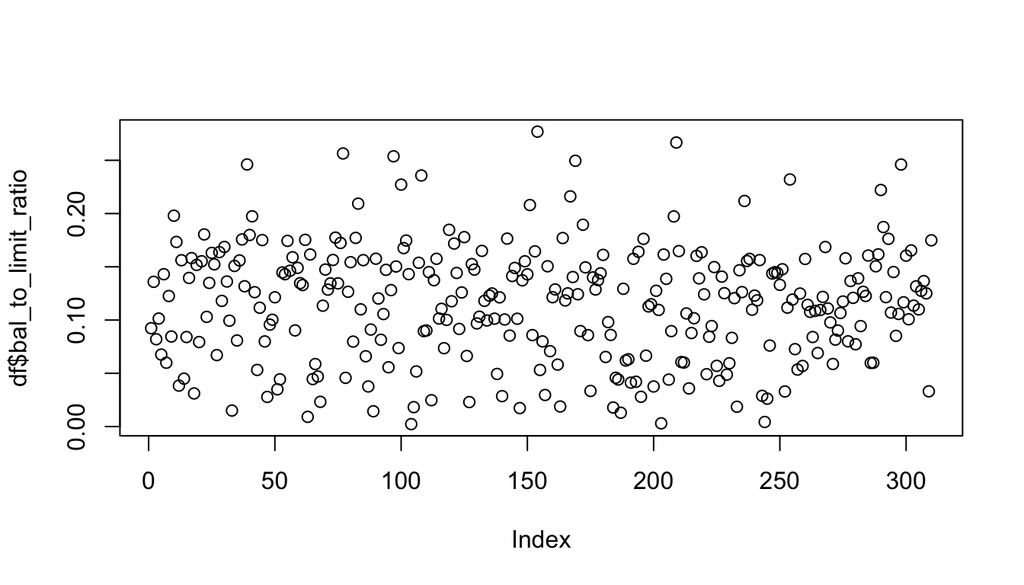

```r
plot(df$bal_to_limit_ratio)
```

So we can see that it is a completely scattered diagram

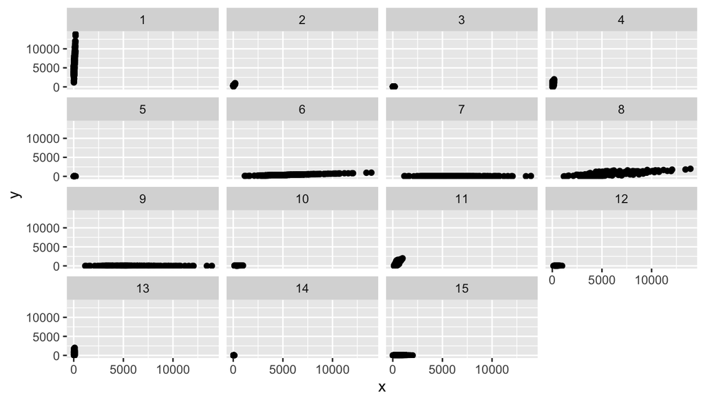

```r
library(dplyr)
library(ggplot2)
data(df)
list(
  transmute(df, x=Income, y=Limit, dataset=1),
  transmute(df, x=Income, y=Rating, dataset=2),
  transmute(df, x=Income, y=Age, dataset=3),
  transmute(df, x=Income, y=Balance, dataset=4),
  transmute(df, x=Income, y=bal_to_limit_ratio, dataset=5),
  transmute(df, x=Limit, y=Rating, dataset=6),
  transmute(df, x=Limit, y=Age, dataset=7),
  transmute(df, x=Limit, y=Balance, dataset=8),
  transmute(df, x=Limit, y=bal_to_limit_ratio, dataset=9),
  transmute(df, x=Rating, y=Age, dataset=10),
  transmute(df, x=Rating, y=Balance, dataset=11),
  transmute(df, x=Rating, y=bal_to_limit_ratio, dataset=12),
  transmute(df, x=Age, y=Balance, dataset=13),
  transmute(df, x=Age, y=bal_to_limit_ratio, dataset=14),
  transmute(df, x=Balance, y=bal_to_limit_ratio, dataset=15)
) %>%
bind_rows() %>%
ggplot(aes(x, y)) +
geom_point() + facet_wrap(~ dataset)
```

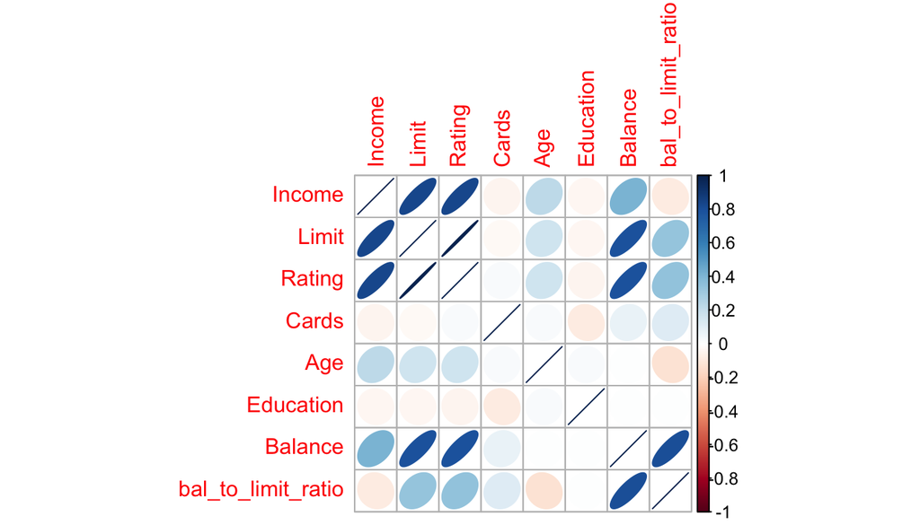

```r
library(corrplot)
corrplot(cor(df.new), method = "ellipse")
```

From here we can say that there is positive association between (x=Income, y=Limit), ( x=Income, y=Rating), ( x=Income, y=Age), ( x=Income, y=Balance),

( x=Balance, y=bal_to_limit_ratio). Negative association between ( x=Income, y=bal_to_limit_ratio), ( x=Age, y=bal_to_limit_ratio),(education,cards) and almost no association between (cards, rating),(cards,age),(age,education) etc.

```r
library(dplyr)
library(ggplot2)
dfnew=df %>%
  dplyr:: select(Income,Age) %>%
  gather()
dfnew
```

[output not shown]

[output cut: 606 more lines]

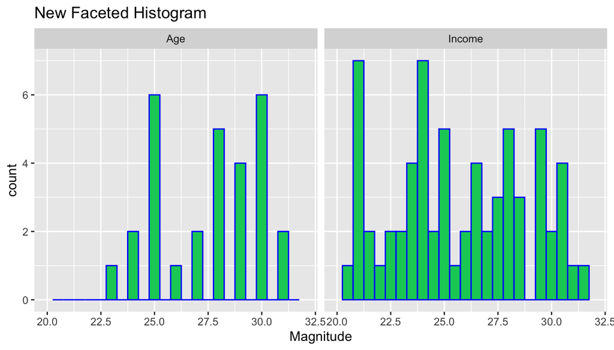

```r
df7=dfnew %>%
  ggplot( mapping=aes(x=value))+
  geom_histogram(color="blue",fill="springgreen3",bins=25) +scale_x_continuous(lim = c(20, 32))
df7+ facet_wrap(~key)+labs(x = "Magnitude")+ggtitle("New Faceted Histogram")
```

```r
# df %>%
#   ggplot(aes(x=Cost))+
#   geom_histogram(color="blue",fill="springgreen3")
```

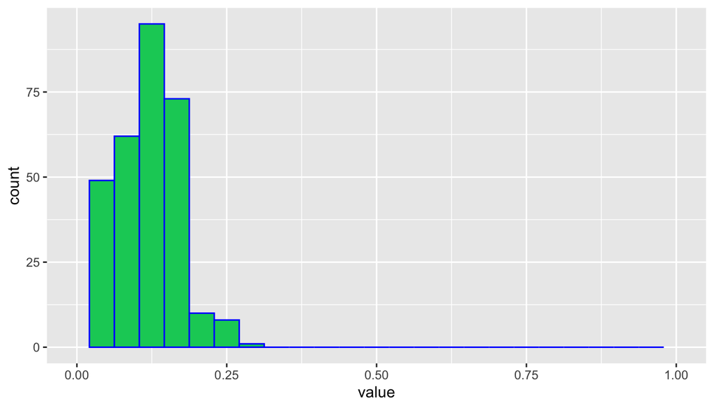

```r
library(dplyr)
library(ggplot2)
dfnew=df %>%
  dplyr:: select(bal_to_limit_ratio) %>%
  gather()
dfnew %>%
  ggplot( mapping=aes(x=value))+
  geom_histogram(color="blue",fill="springgreen3",bins=25) +scale_x_continuous(lim = c(0, 1))
```

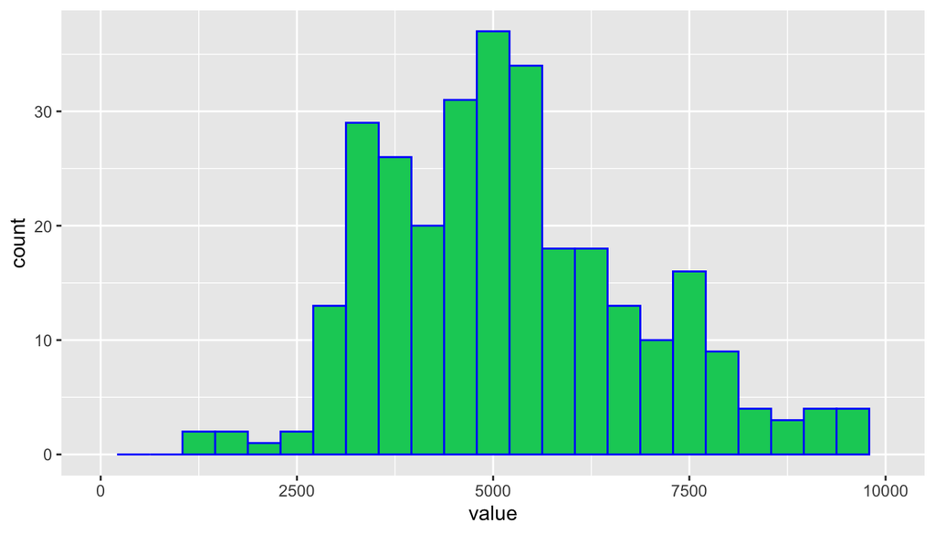

```r
library(dplyr)
library(ggplot2)
dfnew=df %>%
  dplyr:: select(Limit) %>%
  gather()
dfnew %>%
  ggplot( mapping=aes(x=value))+
  geom_histogram(color="blue",fill="springgreen3",bins=25) +scale_x_continuous(lim = c(0, 10000))
```

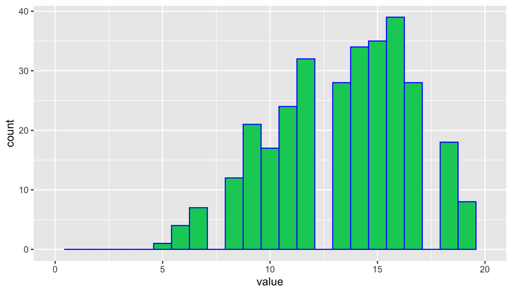

```r
library(dplyr)
library(ggplot2)
dfnew=df %>%
  dplyr:: select(Education) %>%
  gather()
dfnew %>%
  ggplot( mapping=aes(x=value))+
  geom_histogram(color="blue",fill="springgreen3",bins=25) +scale_x_continuous(lim = c(0, 20))
```

These are histogram representation of Question 2.

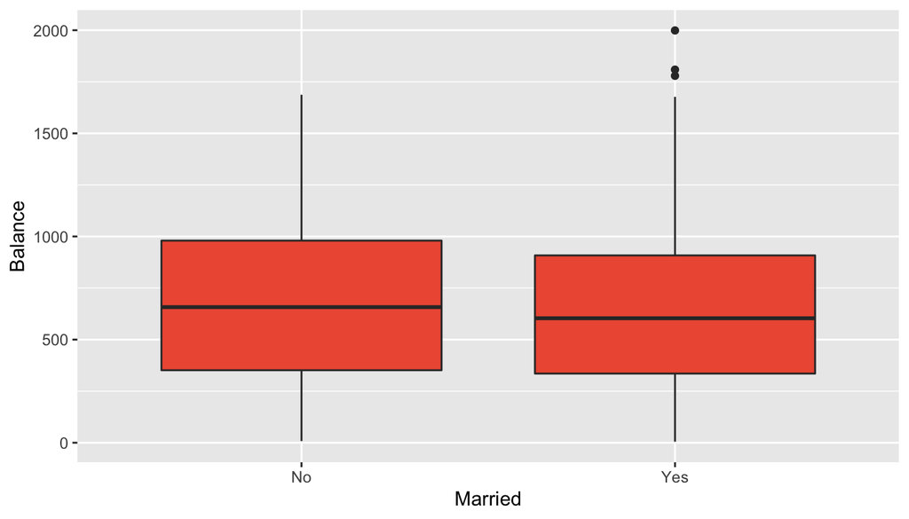

```r
boxplot=ggplot(data=df,mapping=aes(x=Married,y=Balance)) +
  geom_boxplot(fill="tomato2")
boxplot
```

```r
library(GGally)
```

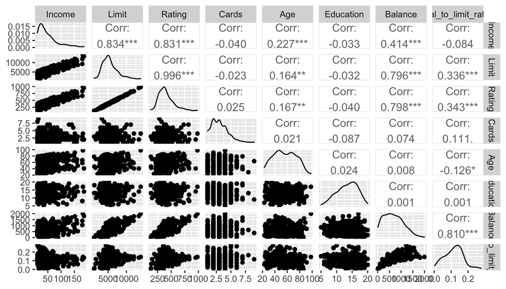

```r
library(ggplot2)
ggpairs(df.new)
```